# ME613A - Análise de Regressão

Atividade Prática 01 - 2S2025 - 27/08/2025

## Introdução

Uma empresa de pesquisa (Last Resource, Inc., Bellefonte, PA) fez um estudo para verificar qual a relação entre a idade do motorista e a distância que ele consegue enxergar bem.

Foi coletada uma amostra de $n = 30$ motoristas, na qual perguntaram a idade do motorista e mediram a distância (em pés) que eles conseguiam enxergar bem um sinal de trânsito. Esses dados estão disponíveis no Moodle, no arquivo chamado *signdist.txt*.

```r
#Importando bibliotecas
library(ggplot2)
library(readr)
library(tidyr)
library(tidyverse)
library(stringr)
library(magrittr)
library(lubridate)
library(knitr)
library(dplyr)
library(kableExtra)
```

## Atividade

1. Leia o conjunto de dados no R e faça um gráfico de dispersão para visualizar a relação entre a idade (variável preditora $X$) e distância (variável resposta $Y$).

```r
dados = read_delim("signdist.txt", show_col_types = FALSE)
head(dados)
```

```
## # A tibble: 6 × 2
##     Age Distance
##   <dbl>    <dbl>
## 1    18      510
## 2    20      590
## 3    22      560
## 4    23      510
## 5    23      460
## 6    25      490
```

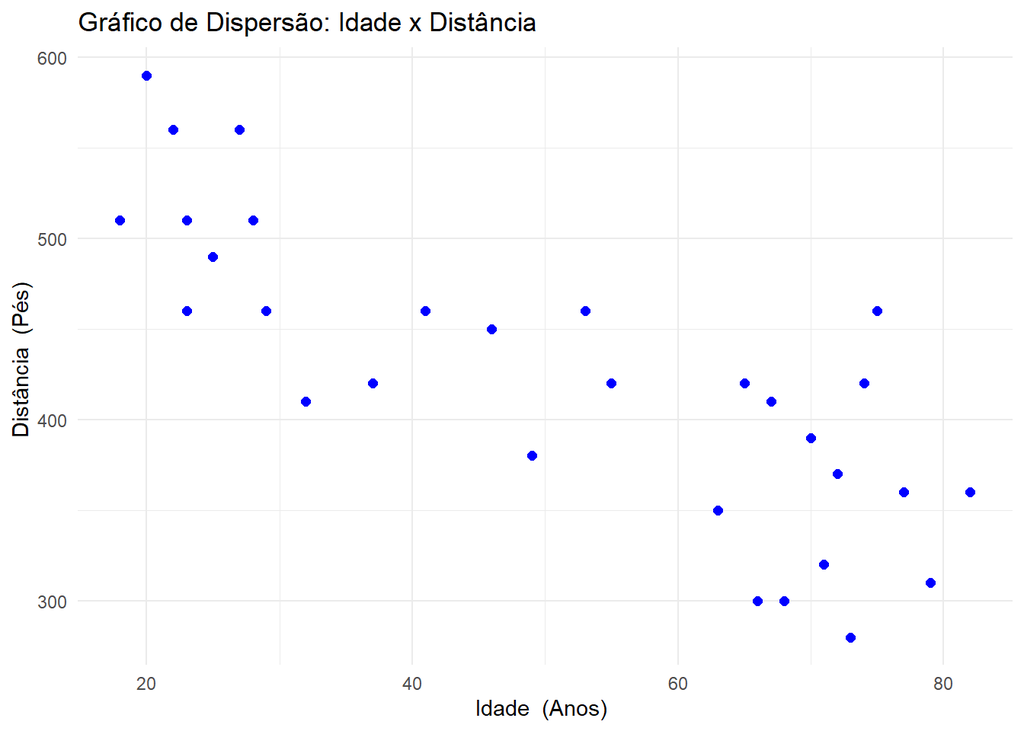

```r
#Idade
x =  dados$Age
#Distância
y=dados$Distance

obs = nrow(dados)

# Criando um  gráfico de dispersão para poder visualizar melhor  a relação entre a idade (variável preditora X) e distância (variável resposta Y)

 ggplot(dados, aes(x = dados$Age, y = dados$Distance)) +
  geom_point(color = "blue", size = 2) +
  labs(title = "Gráfico de Dispersão: Idade x Distância",
       x = "Idade  (Anos) ",
       y = "Distância  (Pés) ") +
  theme_minimal()
```

2. Calcule as estatísticas descritivas das variáveis e também o coeficiente de correlação entre elas.

```r
dados %>%
    summary() %>%
    kable(caption = "Table1a 1. Estatisticas Sumarias") %>%
    kable_styling(full_width = F, position = "center")
```

Table1a 1. Estatisticas Sumarias

|  | Age | Distance |
| --- | --- | --- |
|  | Min. :18.00 | Min. :280.0 |
|  | 1st Qu.:28.25 | 1st Qu.:362.5 |
|  | Median :54.00 | Median :420.0 |
|  | Mean :51.00 | Mean :423.3 |
|  | 3rd Qu.:70.75 | 3rd Qu.:460.0 |
|  | Max. :82.00 | Max. :590.0 |

```r
correlaction = round(cor(dados$Age, dados$Distance),3)
# Média Idade
x_barra = round(mean(dados$Age),2)
y_barra = round(mean(dados$Distance),2)

# Variância
var_x = round(var(dados$Age),2)
var_y = round(var(dados$Distance),2)

# Desvio padrão
desvio_padrao_x =round(sd(dados$Age),2)
desvio_padrao_y =round(sd(dados$Distance),2)
```

A correlação entre idade e distância é **-0.801**

Médias:

A média de idade é **51**  
A média de distância é **423.33**

Variâncias:

A variância da idade é **474.21**  
A variância da distância é **6678.16**

Desvio Padrão:

O desvio padrão da idade é **21.78**  
O desvio padrão da distância é **81.72**

3. Utilizando o R como uma calculadora simples, calcule as estatísticas de interesse que serão posteriormente utizadas para encontrar os estimadores de $\beta_0$ e $\beta_1$.

```r
# Numerador e denominador de beta1
numerador <- sum((x - x_barra) * (y - y_barra))
denominador <- sum((x - x_barra)^2)

# Cálculo manual de beta1 y beta0
beta1 <- numerador / denominador
beta0 <- y_barra - beta1 * x_barra

# Mostrar resultados
# beta1
# beta0
```

#**Estimadores:**

#$\beta_0$ = **576.6786038**  
#$\beta_1$ = **-3.0068354**

4. Usando as estatísticas do item anterior, escreva uma função que, para um dado conjunto de dados, retorna as estimativas de $\hat \beta_0$ e $\hat \beta_1$. **Nota**: não usar a função `lm()`.

```r
# Função para calcular os coeficientes manualmente
calcular_betas <- function(x, y) {
  x_barra_2 <- mean(x)
  y_barra_2 <- mean(y)

  numerador <- sum((x - x_barra_2) * (y - y_barra_2))
  denominador <- sum((x - x_barra_2)^2)

  beta_1 <- numerador / denominador
  beta_0 <- y_barra_2 - beta_1 * x_barra_2

  return(c(beta0 = beta_0, beta1 = beta_1))
}

calcular_betas(dados$Age,dados$Distance)
```

```
##      beta0      beta1
## 576.681937  -3.006835
```

5. Ajuste o modelo de regressão linear simples utilizando a função `lm()` e compare os resultados obtidos no item 3. **Dica**: use as funções `summary()` ou `coef()` para visualizar os coeficientes estimados.

```r
# Agora comparamos os estimadores que encontramos de forma manual com os encontrados da função lm()
calcular_betas(dados$Age,dados$Distance)
```

```
##      beta0      beta1
## 576.681937  -3.006835
```

```r
modelo <- lm(dados$Distance ~ dados$Age, data = dados)
# Visualizar os coeficientes
coef(modelo)
```

```
## (Intercept)   dados$Age
##  576.681937   -3.006835
```

```r
summary(modelo)
```

```
##
## Call:
## lm(formula = dados$Distance ~ dados$Age, data = dados)
##
## Residuals:
##     Min      1Q  Median      3Q     Max
## -78.231 -41.710   7.646  33.552 108.831
##
## Coefficients:
##             Estimate Std. Error t value Pr(>|t|)
## (Intercept) 576.6819    23.4709  24.570  < 2e-16 ***
## dados$Age    -3.0068     0.4243  -7.086 1.04e-07 ***
## ---
## Signif. codes:  0 '***' 0.001 '**' 0.01 '*' 0.05 '.' 0.1 ' ' 1
##
## Residual standard error: 49.76 on 28 degrees of freedom
## Multiple R-squared:  0.642,  Adjusted R-squared:  0.6292
## F-statistic: 50.21 on 1 and 28 DF,  p-value: 1.041e-07
```

6. Apresente um gráfico de dispersão dos dados juntamente com a reta de regressão ajustada. Escreva um parágrafo com as interpretação dos parâmetros. **Nota**: utilize a função `geom_abline()`. Você não deve usar a função `geom_smooth()`.

[figure not shown]

```r
#coef(modelo)[1] BETA_ZERO
#coef(modelo)[2] BETA_UM

coeficiente_linear <- round(coef(modelo)[1],2)
coeficiente_angular <- round(coef(modelo)[2],2)



ggplot(dados, aes(x = dados$Age, y = dados$Distance)) +
    geom_point(color = "blue", size = 2, alpha = 0.7) +
    geom_abline(
        intercept = coeficiente_linear,
        slope = coeficiente_angular,
        color = "red",
        linewidth = 1,
        linetype = "solid"
    ) +
    labs(
        title = "Reta de Regressão Linear Ajustada",
        subtitle = paste("Equação : Distancia =", round(coeficiente_linear, 2), "+", round(coeficiente_angular, 2), "* Idade"),
        x = "Idade (Anos)",
        y = "Distância (Metros)"
    ) +
    theme_minimal() +
    theme(
        plot.title = element_text(hjust = 0.5, face = "bold"),
        plot.subtitle = element_text(hjust = 0.5)
    )
```

**INTERPRETAÇÃO DOS COEFICIENTES:**

**O coeficiente linear ($\beta_0$ = 576,68 unidades)** representa o valor teórico máximo de alcance visual para um indivíduo com idade zero,sendo o ponto de partida da reta de regressão. Este valor corresponde ao maior alcance visual possível na ausência de influência do fator envelhecimento.

**O coeficiente angular ($\beta_1$ = -3,01 unidades/ano)** indica que a cada ano adicional de idade, ocorre uma redução média de 3,01 unidades no alcance visual. Esta taxa de declínio demonstra o efeito cumulativo do envelhecimento sobre a capacidade visual.

Em termos práticos: Enquanto o intercepto estabelece o potencial visual teórico inicial(Uma pessoa com zero anos de idade), o coeficiente angular quantifica o impacto(relação entre idade e o alcance visual) progressivo do envelhecimento, resultando em uma perda gradual do alcance visual ao longo dos anos.

7. Utilizando as fórmulas dadas em aula, encontre as estimativas das variâncias de $\varepsilon$, $\beta_0$ e $\beta_1$. Verifique os cálculos com os resultados apresentados na tabela dos coeficientes estimados obtida no R.

```r
#varepsilon = MSE
 summary(lm(dados$Distance ~ dados$Age, data = dados))
```

```
##
## Call:
## lm(formula = dados$Distance ~ dados$Age, data = dados)
##
## Residuals:
##     Min      1Q  Median      3Q     Max
## -78.231 -41.710   7.646  33.552 108.831
##
## Coefficients:
##             Estimate Std. Error t value Pr(>|t|)
## (Intercept) 576.6819    23.4709  24.570  < 2e-16 ***
## dados$Age    -3.0068     0.4243  -7.086 1.04e-07 ***
## ---
## Signif. codes:  0 '***' 0.001 '**' 0.01 '*' 0.05 '.' 0.1 ' ' 1
##
## Residual standard error: 49.76 on 28 degrees of freedom
## Multiple R-squared:  0.642,  Adjusted R-squared:  0.6292
## F-statistic: 50.21 on 1 and 28 DF,  p-value: 1.041e-07
```

```r
#Sxx - Soma dos Quadrados de X
sxx <- sum((x - x_barra)^2)
#Sxy - Soma dos Produtos Cruzados
sxy <- sum((x - x_barra) * (y - y_barra))
#Syy - Soma dos Quadrados de Y
syy <- sum((y - y_barra)^2)

b1 <- sxy / sxx
b0 <- mean(y) - beta1 * mean(x)


# Previsões e resíduos
y_hat <- b0 + b1 * x
residuos <- y - y_hat
SQE <- sum(residuos^2)

# Variância do erro σ²
s2 <- SQE / (obs - 2)

# Variâncias dos coeficientes
var_beta1 <- s2 / sxx
var_beta0 <- s2 * (1/obs + x_barra^2 / sxx)

# Erros padrão
se_beta0 <- sqrt(var_beta0)
se_beta1 <- sqrt(var_beta1)
```

**Estimativas:**

#Variância de $\varepsilon$ = **2476.2151479**

#Variância de $\beta_0$ = **550.8822443**

#Variância de $\beta_1$ = **0.1800622**

8. Encontre os intervalos de confiança de 90% para $\beta_0$ e $\beta_1$ da seguinte forma:
   1. usando as fórmulas dadas em aula

```r
coeficientes <- coef(modelo)
erros <- summary(modelo)$coefficients[, 2]

# Graus de liberdade
gl <- obs - 2

# Valor crítico t para 90% de confiança
t_critico <- qt(0.95, df = gl)

# Intervalo de confiança para β0 (intercepto)
ic_b0 <- coeficientes[1] + c(-1, 1) * t_critico * erros[1]
cat("IC 90% manual para intercepto:", round(ic_b0[1], 2), "-", round(ic_b0[2], 2), "\n")
```

```
## IC 90% manual para intercepto: 536.75 - 616.61
```

```r
# Intervalo de confiança para  β1 coeficiente angular
ic_b1 <- coeficientes[2] + c(-1, 1) * t_critico * erros[2]
cat("IC 90% manual para coeficiente angular:", round(ic_b1[1], 2), "-", round(ic_b1[2], 2), "\n")
```

```
## IC 90% manual para coeficiente angular: -3.73 - -2.28
```

2. usando a função `confint()`

```r
# Usando confint():
#para beta0 e beta1
confint(modelo, level=0.90)
```

```
##                    5 %       95 %
## (Intercept) 536.754896 616.608979
## dados$Age    -3.728689  -2.284982
```

**Intervalos de confiança**

Intervalo de confiança de 90% para $\beta_0$ [**536.7548958** ; **616.6089785**]

Intervalo de confiança de 90% para $\beta_1$ [**-3.7286888** ; **-2.284982**]

9. Apresente um teste de hipótese para verificar se o coeficiente $\beta_1$ é nulo o, u não, usando o seguinte:
   1. Teste t

```r
#H0: beta1 = 0
#H1: beta1 !=0
#alfa: 5%

resumo <- summary(modelo)

t_estatistico <- resumo$coefficients[2, 3]
p_valor <- resumo$coefficients[2, 4]

# 1) Valores previstos y residuos
y_previsto <- beta0 + beta1 * dados$Age
residuos   <- dados$Distance - y_previsto

# 2) Varianza residual para inferencia: s^2 = SSE / (n - 2)
SSE <- sum(residuos^2)
s2  <- SSE / (obs - 2)       # <-- en lugar de mean(residuos^2)

# 3) Teste t para H0: beta1 = 0
se_beta1  <- sqrt(s2 / sxx)
tobservado <- beta1 / se_beta1
tcritico   <- qt(p = 0.05/2, df = obs - 2, lower.tail = FALSE)

teste_t <- function(tobservado, tcritico){
  if (abs(tobservado) > tcritico) {
    print("Rejeito H0 considerando o nivel de significancia de 5%")
  } else {
    print("Não rejeito a Hipotese nula considerando o nivel de significancia de 5%")
  }
}
teste_t(tobservado, tcritico)
```

```
## [1] "Rejeito H0 considerando o nivel de significancia de 5%"
```

**Existe uma relação linear estatisticamente significante entre Idade e Distância portanto o coeficiente** $\beta_1$ **não é nulo**

**Estatística de teste :** **-7.0859551**

**p-valor :1.0409976^{-7}**

```
(b) Teste F
```

```r
#H0: beta1 = 0
#H1: beta1 !=0
#alfa: 5%

# Componentes ANOVA y Teste F
SST   <- sum( (dados$Distance - y_barra)^2 )   # SQT
SSR   <- SST - SSE                             # SQReg
QMReg <- SSR / 1
QMRes <- SSE / (obs - 2)

Fobs    <- QMReg / QMRes                       # = tobs^2
pvalorF <- pf(Fobs, df1 = 1, df2 = obs - 2, lower.tail = FALSE)

cat("Teste F:\n",
    "F observado =", round(Fobs, 3),
    "| gl1 = 1, gl2 =", obs - 2,
    "| p-valor =", signif(pvalorF, 5), "\n")
```

```
## Teste F:
##  F observado = 50.211 | gl1 = 1, gl2 = 28 | p-valor = 1.041e-07
```

```r
# Verificación de la equivalencia F = t^2
c(F_observado = Fobs, t2 = tobservado^2)  # usa tobsservado o renombra a 'tobservado'
```

```
## F_observado          t2
##    50.21076    50.21076
```

```r
# (y la ANOVA del modelo de R)
# anova(model_distancia)
anova(modelo)
```

```
## Analysis of Variance Table
##
## Response: dados$Distance
##           Df Sum Sq Mean Sq F value    Pr(>F)
## dados$Age  1 124333  124333  50.211 1.041e-07 ***
## Residuals 28  69334    2476
## ---
## Signif. codes:  0 '***' 0.001 '**' 0.01 '*' 0.05 '.' 0.1 ' ' 1
```

**O modelo de regressão é estatisticamente significante e nesse caso rejeitamos a hipotese nula** $\beta_1$ **não é nulo**

**p-valor :1.0409976^{-7}** **<**$\alpha$

10. Calcule o coeficiente de determinação $R^2$ e interprete-o.

```r
# Somas de quadrados

SST <- sum( (y - y_barra)^2 )   # SQT (total)
SSR <- SST - SQE                 # SQReg (regressão)

# R^2 manual
R2 <- SSR / SST
R2
```

```
## [1] 0.641993
```

```r
# (opcional) R^2 ajustado, por si quieres reportarlo también:
R2_ajustado <- 1 - (SQE / (obs - 2)) / (SST / (obs - 1))
R2_ajustado
```

```
## [1] 0.629207
```

```r
# Verificación com o lm:
summary(modelo)$r.squared
```

```
## [1] 0.641993
```

```r
summary(modelo)$adj.r.squared
```

```
## [1] 0.629207
```

**INTERPRETAÇÃO DE $R^2$:**

O coeficiente de determinação $R^2$ é uma medida estatística que indica o quão bem o modelo de regressão se ajusta aos dados observados, ou seja, explica-nos quanto da variável dependente pode ser explicado pelas variáveis independentes. No nosso caso, a variável dependente é a distância visual dos motociclistas e a variável independente é a idade do motociclista. De acordo com os cálculos realizados, o $R^2$ é de 0,64, o que interpretamos como 64% da variabilidade da distância em que os motociclistas podem ver um sinal pode ser explicada pela idade dos motociclistas. O fato de ser 64% significa que a idade é um fator importante que influencia a distância visual que um motociclista é capaz de perceber, mas também indica que existem outros fatores não observados que influenciam a capacidade do motociclista.

11. Centralize a variável preditora em sua média e ajuste uma regressão simples novamente. Compare o resultado com aquele obtido no item 4.

```r
# 1) Crear la X centrada
dados$Age_c <- dados$Age - x_barra

# 2) Ajustar el modelo centrado
modelo_c <- lm(Distance ~ Age_c, data = dados)

# 3) Coeficientes del modelo centrado
b0_c <- coef(modelo_c)[1]
b1_c <- coef(modelo_c)[2]

# 4) Comparaciones clave con el ítem 4
comp_betas <- rbind(
  original = c(beta0 = b0,      beta1 = b1),
  centrado = c(beta0 = b0_c,    beta1 = b1_c),
  esperado = c(beta0 = y_barra, beta1 = b1)  # teoría con X centrada
)
comp_betas
```

```
##             beta0     beta1
## original 576.6819 -3.006835
## centrado 423.3333 -3.006835
## esperado 423.3300 -3.006835
```

```r
# 5) Comprobar que Age_c tiene media 0
mean_Age_c <- mean(dados$Age_c)

# 6) Verificar que el ajuste esencial no cambia
#    (mismos fitted y mismos residuos; mismo R^2)
eq_fitted   <- all.equal(fitted(modelo),  fitted(modelo_c))
eq_residuos <- all.equal(residuals(modelo), residuals(modelo_c))
R2_orig     <- summary(modelo)$r.squared
R2_cent     <- summary(modelo_c)$r.squared

list(
  mean_Age_c = mean_Age_c,
  fitted_iguais = eq_fitted,
  residuos_iguais = eq_residuos,
  R2_original = R2_orig,
  R2_centrado = R2_cent
)
```

```
## $mean_Age_c
## [1] 0
##
## $fitted_iguais
## [1] TRUE
##
## $residuos_iguais
## [1] TRUE
##
## $R2_original
## [1] 0.641993
##
## $R2_centrado
## [1] 0.641993
```

**Comparando com o item 4:** No item 4, o modelo de regressão linear simples ajustado com a idade original resultou em **$\beta_0$=576,68** e **$\beta_1$=−3,0068**. O que, em teoria, explica que um motociclista de 0 anos teria uma distância visual de 576 pés, o que não faz sentido prático, enquanto cada ano adicional de idade reduz em média 3 pés da distância de visibilidade. Nesta seção, ao centrar a variável idade em torno de sua média, o modelo manteve a mesma inclinação **$\beta_1$=−3,0068**; isso confirma que o efeito da idade sobre a distância não muda. Mas a interceptação passou a ser $\beta_0$=423,33, que é o valor que coincide aproximadamente com a média da distância. Dessa forma, a interceptação agora representa a distância média de visibilidade para um motorista de idade média na amostra; isso torna a interpretação mais realista e coerente. Quando observamos os dois modelos, o coeficiente de determinação é o mesmo ($R^2$), o que indica que aproximadamente 64,2% da variabilidade na distância visual é explicada pela idade.

12. Se você transformar a distância de pés para metros, como isso afeta os coeficientes da regressão? Note que 1 pé = 0,3048 metros.

```r
# Conversión de pies a metros
factor <- 0.3048

# Coeficientes originales en pies
b0_pies <- 576.68
b1_pies <- -3.0068

# Coeficientes convertidos a metros
b0_metros <- b0_pies * factor
b1_metros <- b1_pies * factor

c(beta0_metros = b0_metros,
  beta1_metros = b1_metros)
```

```
## beta0_metros beta1_metros
##  175.7720640   -0.9164726
```

**Interpretação em Metros:** Após converter a distância em metros:

A interceptação passa a ser a distância média de um motociclista de 0 anos (teórico) em 176 metros. A inclinação indica que, para cada ano adicional de idade, a distância de visibilidade diminui em média 0,915 metros. O ajuste do modelo ($R^2$) não muda, porque a relação linear entre as variáveis continua a mesma; apenas mudam as unidades de medida da variável resposta.